# Part II - (Dataset Explanation Title)

### Distribution of Departure delays

How many minutes does theflight gets delayed for most

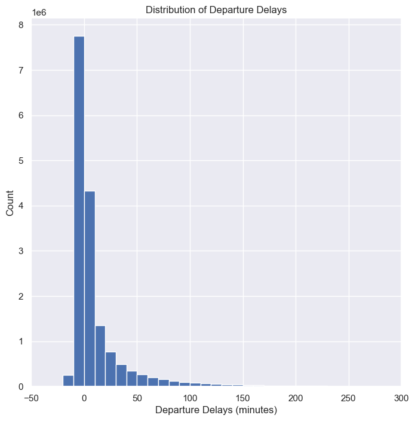

It can be seen from the graph above that the distributionis skewed right and the most of the delays are between **0 and 50**

### Distribution of delayed flights by days and Month

Which days and month had the most delayed flights?

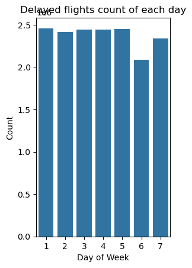

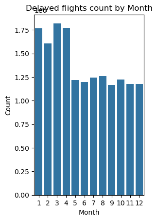

As it can be seen from the graph above, **Day 1 (Sunday)** experienced the most delayed flights  
As it can be seen from the graph above, **Month 3 (March)** experienced the most delayed flights

### Visualization showing the relationship between the numeric variables

The heatmap below will allow us to better understand the correlation between numeric variables in the dataset

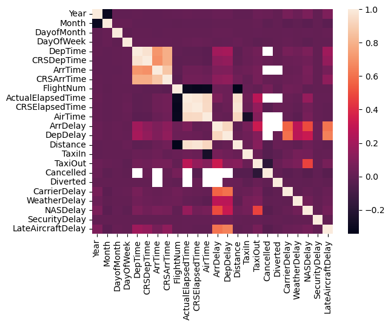

## Conclusions

> The following are the important findings of the above analysis as a result of the above data investigation and exploration:  
> Most cancellation is caused by carrier  
> Envoy Air has the most cancellation  
> The year 2007 experienced the most cancellation  
> February is the month that experience the most flight cancellations  
> Thursday experienced the most cancellation  
> There's no correlation between cancellation and delayed March experienced the most delayed flights  
> Most flights are delayed for 0-50 mins  
> Sunday experioenced the most delayed flights  
> South west Airlines delayed most of their flights